# Assignment 2

John Kellogg

2/20/2021

## Assignment 2

### 3.1

#### For the following series, find an appropriate Box-Cox transformation in order to stabilize the variance.

- usnetelec
- usgdp
- mcopper
- enplanements

```r
(usnetelec_lb <- BoxCox.lambda(usnetelec))
```

```
## [1] 0.5167714
```

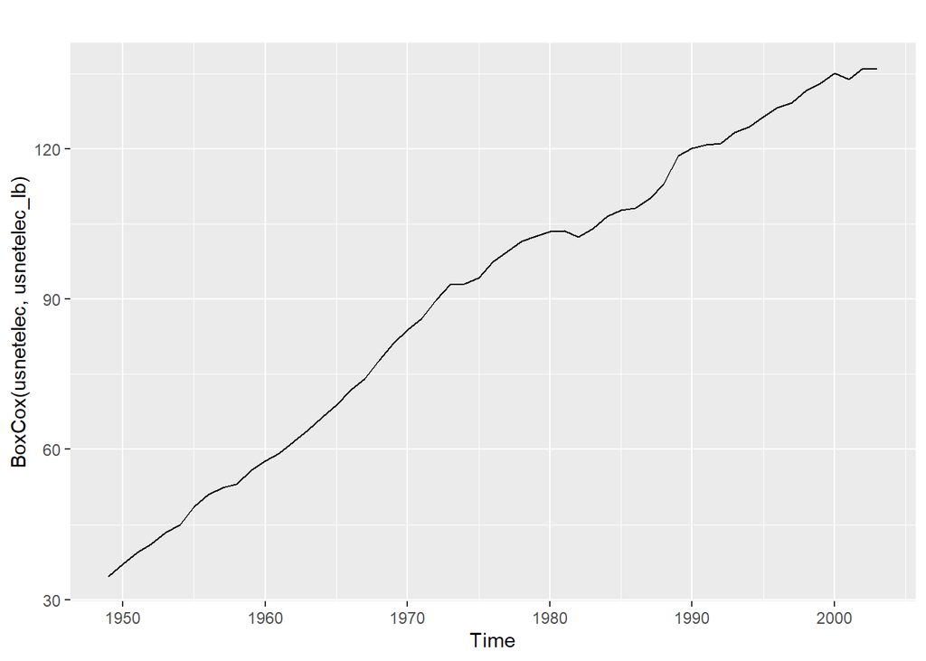

```r
autoplot(BoxCox(usnetelec,usnetelec_lb))
```

```r
(usgdp_lb <- BoxCox.lambda(usgdp))
```

```
## [1] 0.366352
```

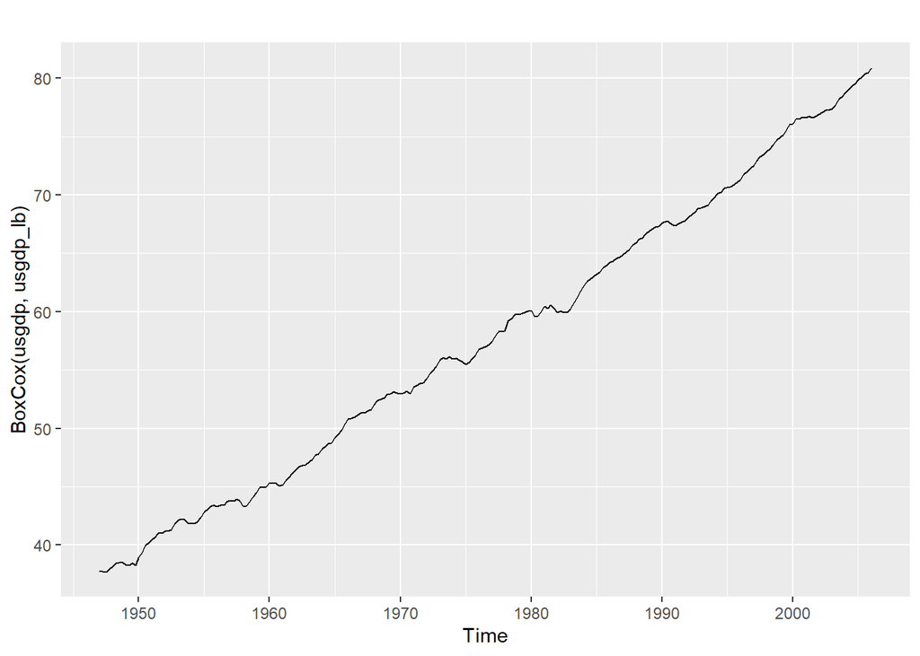

```r
autoplot(BoxCox(usgdp,usgdp_lb))
```

```r
(mcopper_lb <- BoxCox.lambda(mcopper))
```

```
## [1] 0.1919047
```

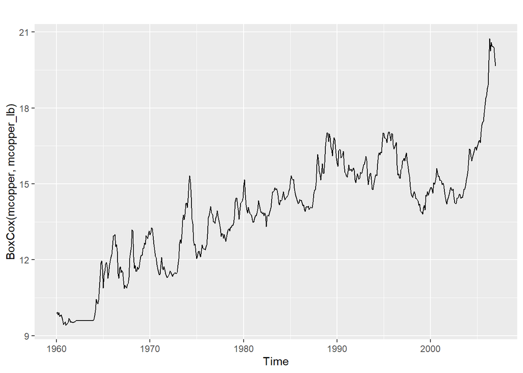

```r
autoplot(BoxCox(mcopper,mcopper_lb))
```

```r
(enplanements_lb <- BoxCox.lambda(enplanements))
```

```
## [1] -0.2269461
```

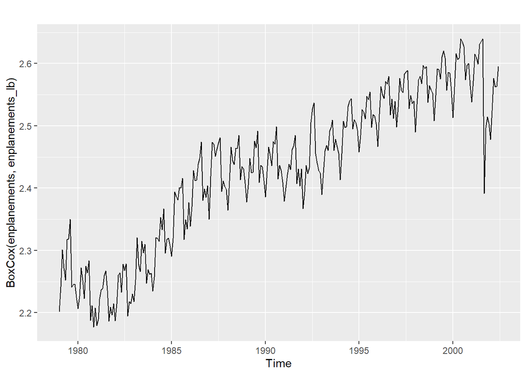

```r
autoplot(BoxCox(enplanements,enplanements_lb))
```

### 3.2

#### Why is a Box-Cox transformation unhelpful for the cangas data?

```r
(cangas_lb <- BoxCox.lambda(cangas))
```

```
## [1] 0.5767759
```

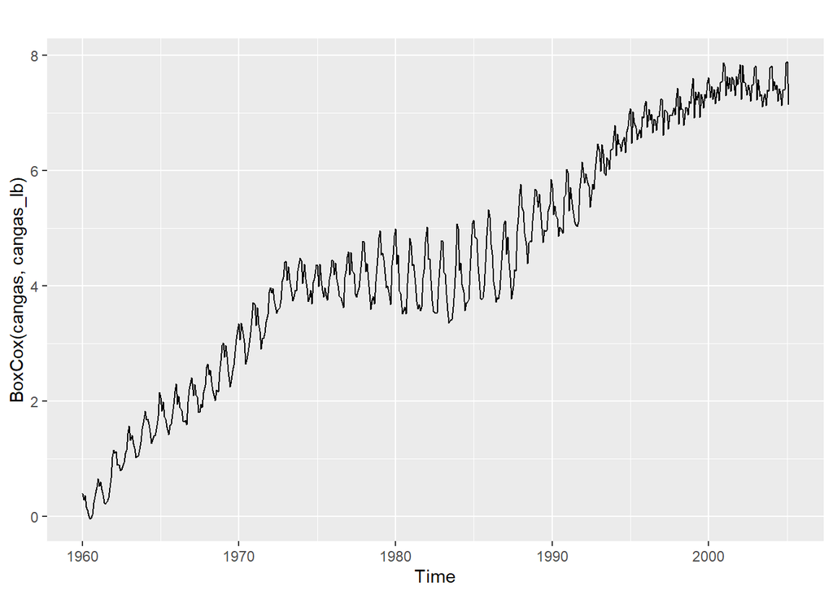

```r
autoplot(BoxCox(cangas,cangas_lb))
```

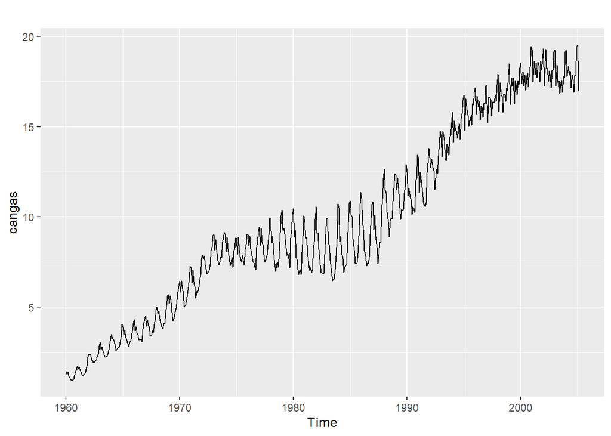

```r
autoplot(cangas)
```

- The transformation does not seem to have effect due to the dependency on lambda. A good lambda value makes the size of the seasonal variation about the same across the series.
- Seasonality, while it exists in this data, is too varying in value to have a good lambda.

### 3.3

#### What Box-Cox transformation would you select for your retail data (from Exercise 3 in Section 2.10)?

```r
retaildata <- read_excel('retail.xlsx', skip=1)
myts <- ts(retaildata[,"A3349640L"],frequency=12, start=c(1982,4))
```

```r
(myts_lb <- BoxCox.lambda(myts))
```

```
## [1] 0.1311965
```

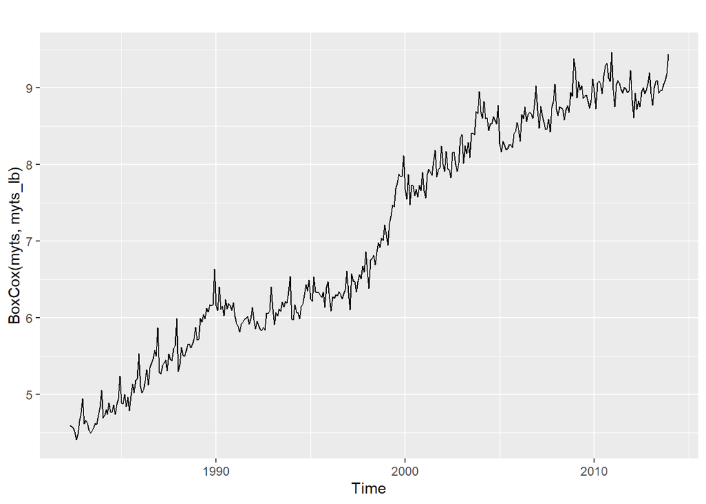

```r
autoplot(BoxCox(myts,myts_lb))
```

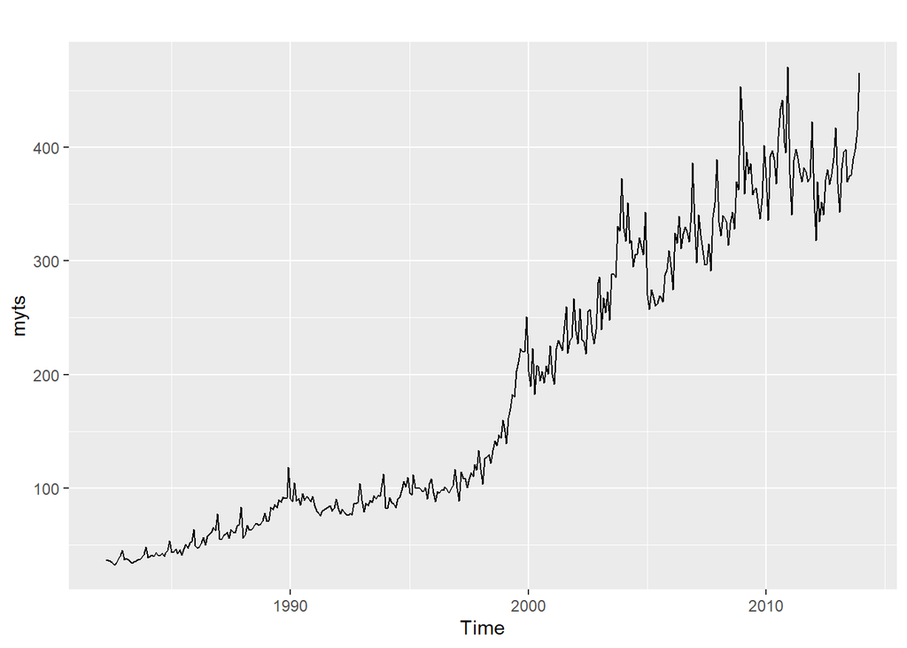

```r
autoplot(myts)
```

- It does appear the BoxCox transformation had effect on the data.

```r
forecast1 <- rwf(myts, drift =TRUE, lambda = myts_lb, h=50, level=80)
forecast2 <- rwf(myts, drift =TRUE, lambda = myts_lb, h=50, level=80, biasadj = TRUE)
```

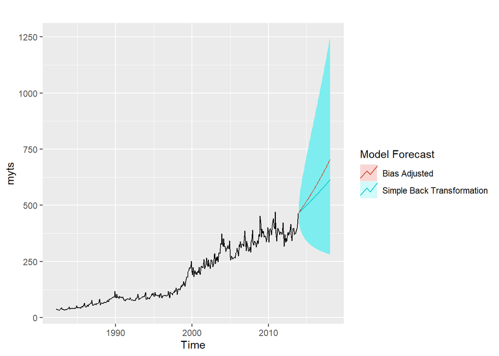

```r
autoplot(myts) +
  autolayer(forecast1, series= 'Simple Back Transformation') +
  autolayer(forecast2, series= 'Bias Adjusted', PI=FALSE) +
  guides(color =guide_legend(title = 'Model Forecast'))
```

- In this instance, I think the simple back transformation matches the flow of the data. The bias adjusted values rise too quickly when looking at the previous values.

### 3.8

#### For your retail time series (from Exercise 3 in Section 2.10):

##### a. Split the data into two parts using:

```r
myts.train <- window(myts, end=c(2010,12))
myts.test <- window(myts, start=2011)
```

##### b. Check that your data have been split appropriately by producing the following plot.

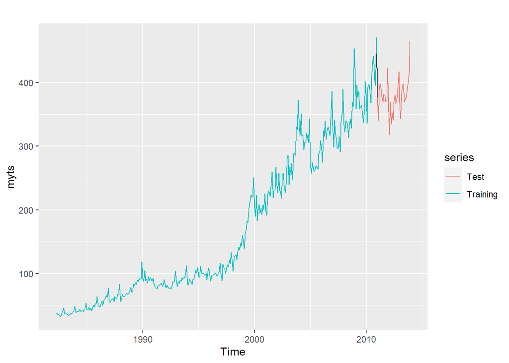

```r
autoplot(myts) +
autolayer(myts.train, series="Training") +
autolayer(myts.test, series="Test")
```

##### c. Calculate forecasts using snaive applied to myts.train.

```r
fc <- snaive(myts.train)
```

##### d. Compare the accuracy of your forecasts against the actual values stored in myts.test.

```r
accuracy(fc,myts.test)
```

```
##                     ME     RMSE      MAE       MPE      MAPE     MASE
## Training set  13.10781 29.87236 20.66937  7.478844 11.485020 1.000000
## Test set     -28.33750 36.99343 29.92083 -7.630292  8.058562 1.447593
##                   ACF1 Theil's U
## Training set 0.8224883        NA
## Test set     0.4432892  1.292012
```

##### e. Check the residuals.

Do the residuals appear to be uncorrelated and normally distributed?

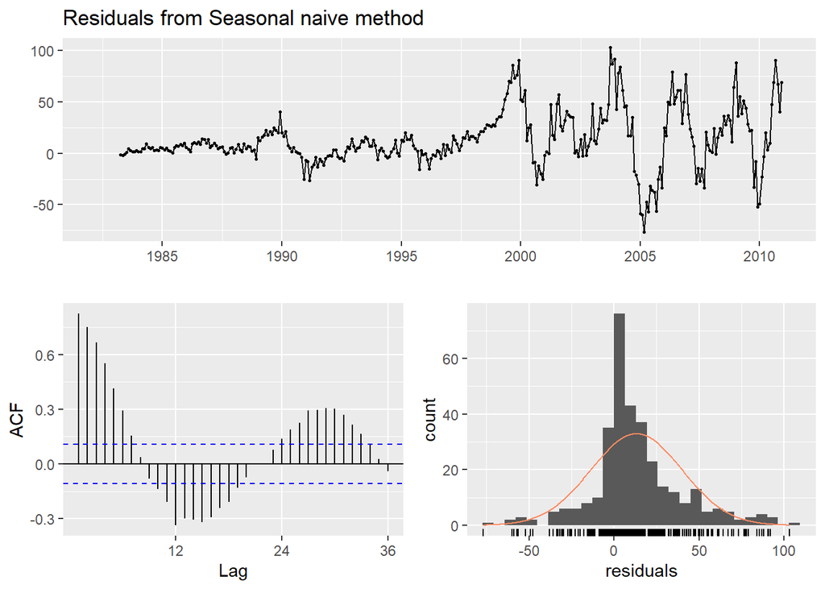

```
##
##  Ljung-Box test
##
## data:  Residuals from Seasonal naive method
## Q* = 1011.9, df = 24, p-value < 2.2e-16
##
## Model df: 0.   Total lags used: 24
```

```r
checkresiduals(fc)
```

- A Q value of 1011.9 suggests auto correlations.
- The Histogram does appear to have a bit of a right skew
- The ACF plot does appear to show the start of seasonality

##### f. How sensitive are the accuracy measures to the training/test split?

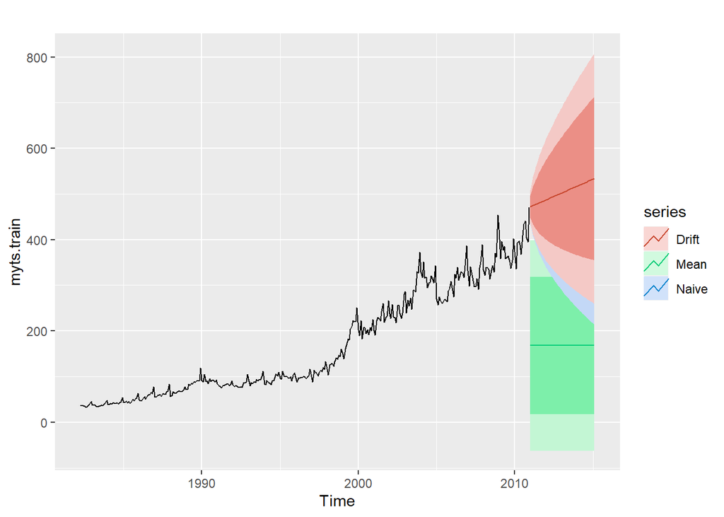

```r
mean1 <- meanf(myts.train,h=50)
forecast1 <- rwf(myts.train, h=50)
forecast2 <- rwf(myts.train, drift =TRUE, h=50)

autoplot(myts.train) +
autolayer(mean1, series="Mean") +
autolayer(forecast1, series="Naive")+
autolayer(forecast2, series = "Drift")+
guides(colors=guide_legend(title = "Forecasts"))
```